# Final Project

29/05/2018

## Model Overfit

My App (https://petersiw.shinyapps.io/final_project/) discusses the problem of overfitting a multivariate model due to inclusion of too many variables by comparing between the R Squared (\(R^2\)) and Adjusted R Squared (\(\bar{R^2}\)).

Using the Airquality data, I created a simple model analysing the relationship between Ozone Levels and Temperature. By adjusting the slider, the user can simulate a model with varying numbers of variables (which are simply the exponents of Temperature).

The model used was \(Ozone~=~\beta_{0}~+~\beta_{1}Temp~+~\beta_{k}Temp^k~+~...~+\beta_{n}Temp^n\) where \(n\) is being varied.

## Plots of the Model Across Different \(n\) Degrees of Polynomial

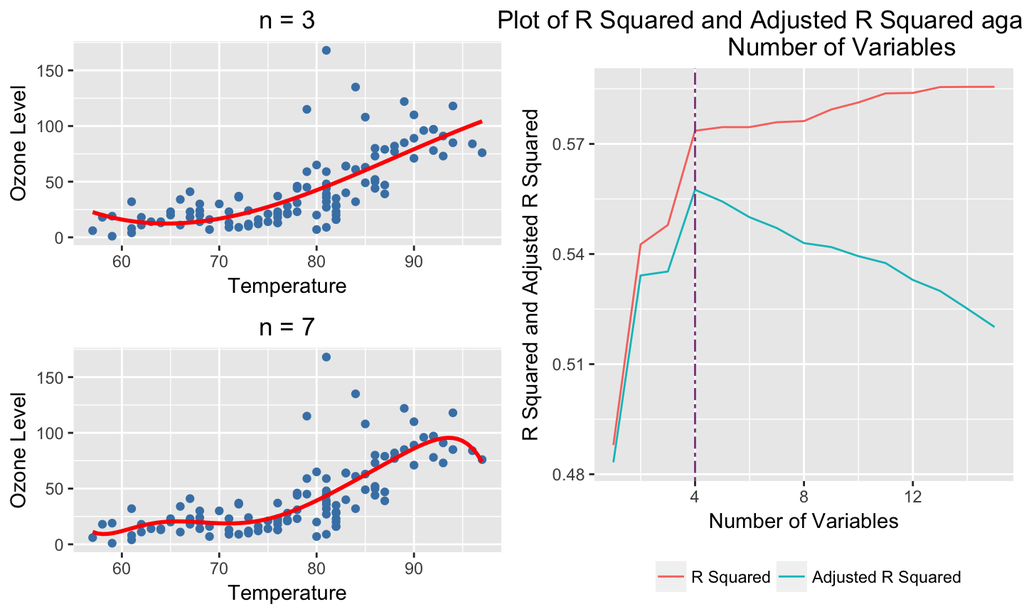

## An Example of Code for the Previous Slide

```r
p4 <- ggplot(data = aq, aes(x = Temp, y = Ozone)) +
      geom_point(colour = "steelblue") +
      labs(title = "n = 7", x = "Temperature", y = "Ozone Level") +
      theme(plot.title = element_text(hjust = 0.5)) +
      geom_smooth(method = "lm", formula = y ~ poly(x, 7),
                  colour = "red", se = F)
```

## Analysis and Conclusion

This is a classic case of overfitting, whereby the model is becoming too close to the data that it becomes biased. Therefore, one must always monitor the \(\bar{R^2}\) of a model to prevent overfitting.